# Integrating scRNA-seq Datasets with Python

- Show All Code
- Hide All Code
- View Source

Author

Affiliation

Jack Leary

University of Florida

Published

January 5, 2024

# Introduction

The need to integrate data from scRNA-seq samples into one harmonized dataset has increased in recent years as single cell sequencing has gotten cheaper, making it easier to collect data from multiple subjects, timepoints, or conditions. The goal of most integration techniques is to create an embedding that is (relatively) free of batch effects and that does not lead to the cells clustering by subject ID. There are many methods available to perform integration in both R & Python, and evaluating which method is “best” for your dataset can be tricky & subjective. In this tutorial we’ll try out several of the integration methods available in the `scanpy` package and compare their results. We’ll use a SmartSeq2 dataset containing myeloid cells from the developing human fetal liver that was originally analyzed in [Popescu *et al* (2020)](https://doi.org/10.1038/s41586-019-1652-y). As such, our goal will be to determine which integration method results in the best embedding for downstream trajectory analysis. In developmental biology settings, a “good” scRNA-seq integrated embedding is smoothly connected (i.e., no spaced-out, discrete clusters), and places celltypes in roughly the order expected based on known biology.

# Libraries

## R

```r
library(dplyr)       # dataframe tools
library(Matrix)      # sparse matrices
library(Seurat)      # scRNA-seq tools
library(ggplot2)     # plots
library(reticulate)  # Python interface
```

## Python

```python
import scvi                          # VAE integration
import warnings                      # filter out warnings
import numpy as np                   # matrix utilities
import scanpy as sc                  # scRNA-seq processing
import pandas as pd                  # dataframe tools
import anndata as ad                 # scRNA-seq data structures
import matplotlib.pyplot as plt      # plot utilities
from scipy.sparse import csr_matrix  # sparse matrices
```

```python
warnings.simplefilter('ignore', category=UserWarning)
```

# Theme for `matplotlib`

Here we define a theme for `matplotlib` that mostly matches `ggplot2::theme_classic()`.

```python
base_size = 12
plt.rcParams.update({
    # font
    'font.size': base_size,
    'font.weight': 'normal',
    # figure
    'figure.dpi': 300,
    'figure.edgecolor': 'white',
    'figure.facecolor': 'white',
    'figure.figsize': (6, 4),
    'figure.constrained_layout.use': True,
    # axes
    'axes.edgecolor': 'black',
    'axes.grid': False,
    'axes.labelpad': 2.75,
    'axes.labelsize': base_size * 0.8,
    'axes.linewidth': 1.5,
    'axes.spines.right': False,
    'axes.spines.top': False,
    'axes.titlelocation': 'left',
    'axes.titlepad': 11,
    'axes.titlesize': base_size,
    'axes.titleweight': 'normal',
    'axes.xmargin': 0.1,
    'axes.ymargin': 0.1,
    # legend
    'legend.borderaxespad': 1,
    'legend.borderpad': 0.5,
    'legend.columnspacing': 2,
    'legend.fontsize': base_size * 0.8,
    'legend.frameon': False,
    'legend.handleheight': 1,
    'legend.handlelength': 1.2,
    'legend.labelspacing': 1,
    'legend.title_fontsize': base_size,
    'legend.markerscale': 1.25
})
```

# Data

We’ll start by reading in the SmartSeq2 scRNA-seq data from [Popescu *et al*](https://doi.org/10.1038/s41586-019-1652-y), which we downloaded from [the Human Developmental Cell Atlas portal](https://developmental.cellatlas.io/fetal-liver). Some massaging of the data is necessary to get it ready to pass into Python.

```r
seu_blood <- readRDS("../../datasets/fetal_liver_SS2.RDS")
class(seu_blood) <- "Seurat"
blood_counts <- as.matrix(seu_blood@raw.data)
blood_counts <- blood_counts[, colnames(seu_blood@scale.data)]
cell_metadata <- seu_blood@meta.data[colnames(seu_blood@scale.data), ] %>%
                 mutate(cell = rownames(.),
                        .before = 1)
gene_metadata <- data.frame(gene = rownames(blood_counts))
```

# Read data into Python

Using the `reticulate` R package we transfer our raw counts matrix and cell & gene metadata into Python, then create an `AnnData` object. Lastly, we rename some cell metadata features and subset to just the macrophage development lineage. This will simplify our trajectory structure and make choosing a good integration / embedding combination easier.

```python
blood_counts = csr_matrix(r.blood_counts.transpose())
cell_metadata = r.cell_metadata
gene_metadata = r.gene_metadata
ad_blood = ad.AnnData(blood_counts)
ad_blood.obs_names = cell_metadata['cell']
ad_blood.var_names = gene_metadata['gene']
ad_blood.obs = cell_metadata
ad_blood.obs.rename(columns={'cell.labels': 'celltype', 'fetal.ids': 'fetal_ID', 'percent.mito': 'percent_MT', 'sort.ids': 'sort_ID'}, inplace=True)
ad_blood = ad_blood[ad_blood.obs['celltype'].isin(['HSC_MPP', 'Neutrophil-myeloid progenitor', 'Monocyte precursor', 'Monocyte', 'Mono-Mac', 'Kupffer Cell'])]
ad_blood.obs['celltype'] = (
    ad_blood.obs['celltype']
              .map(lambda x: {'HSC_MPP': 'HSC', 'Mono-Mac': 'Monocyte-macrophage', 'Kupffer Cell': 'Kupffer cell'}.get(x, x))
              .astype('category')
)
ad_blood.var = gene_metadata
ad_blood
```

```
AnnData object with n_obs × n_vars = 486 × 33660
    obs: 'cell', 'nGene', 'nUMI', 'orig.ident', 'percent_MT', 'fetal_ID', 'sort_ID', 'tissue.id', 'plate.id', 'lanes', 'stages', 'sample.type', 'gender', 'cell.label', 'doublets', 'celltype'
    var: 'gene'
```

# Preprocessing

After removing cells classified as doublets by the original authors, we filter out low-depth cells and genes expressed in less than 10 cells. We then set up a new layer named **counts** containing the raw counts - this is necessary for integration with `scVI`, which takes as input the raw, unnormalized expression estimates. Lastly, we identify 3,000 HVGs and subset our object to just those genes.

```python
ad_blood = ad_blood[ad_blood.obs['doublets'] == 'Singlet']
sc.pp.filter_cells(ad_blood, min_counts=200)
sc.pp.filter_genes(ad_blood, min_cells=10)
ad_blood.layers['counts'] = ad_blood.X.copy()
ad_blood.raw = ad_blood
sc.pp.highly_variable_genes(
    ad_blood,
    n_top_genes=3000,
    flavor='seurat_v3',
    layer='counts',
    subset=True
)
```

# Integration with `scVI`

[Paper](https://doi.org/10.1038/s41592-018-0229-2), [Docs](https://scvi-tools.org)

## Train `scVI` model

We’ll integrate across the ID specifying which fetus the cells came from. We also make `scVI` aware of our celltypes, and instruct it to regress out variation associated with the percentage of mitochondrial reads.

```python
scvi.settings.verbosity = 0
scvi.settings.seed = 312
```

```python
scvi.settings.num_threads = 4
scvi.model.SCVI.setup_anndata(
    ad_blood,
    layer='counts',
    batch_key='fetal_ID',
    labels_key='celltype',
    continuous_covariate_keys=['percent_MT']
)
```

We allow gene dispersion estimates to vary by celltype, and specify expression as following a negative-binomial distribution.

```python
int_model = scvi.model.SCVI(
    ad_blood,
    n_layers=3,
    n_hidden=96,
    n_latent=20,
    gene_likelihood='nb',
    dispersion='gene-label'
)
```

Finally we train a variational autoencoder (VAE) over 250 epochs to embed the cells in 20-dimensional latent space.

```python
int_model.train(
    early_stopping=True,
    accelerator='cpu',
    max_epochs=250,
    train_size=0.8
)
```

```python
ad_blood.obsm['X_scVI'] = int_model.get_latent_representation()
```

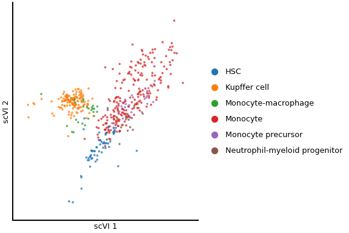

Figure 1: scVI embedding

```python
sc.pl.embedding(
    ad_blood,
    basis='scVI',
    color='celltype',
    title='',
    frameon=True,
    size=30,
    alpha=0.75,
    show=False
)
plt.gca().set_xlabel('scVI 1')
plt.gca().set_ylabel('scVI 2')
plt.show()
```

## SNN graph estimation

We use the cosine distance to identify 20 NNs for each cell in the latent `scVI` space. This neighbor graph will serve as the basis for our nonlinear embeddings.

```python
sc.pp.neighbors(
    ad_blood,
    n_neighbors=20,
    n_pcs=None,
    metric='cosine',
    random_state=312,
    use_rep='X_scVI'
)
```

## UMAP embedding

Using default parameters, we fit a 2D UMAP embedding.

```python
sc.tl.umap(ad_blood, random_state=312)
```

The UMAP embedding is a bit oddly-shaped, but celltypes are well-connected and their progression follows known biology i.e., HSCs form precursor populations which develop into mature monocytic cells.

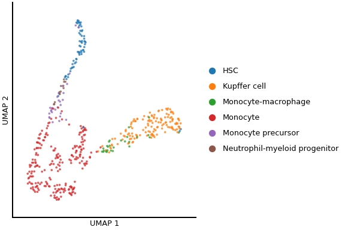

Figure 2: scVI-based UMAP embedding

```python
sc.pl.embedding(
    ad_blood,
    basis='umap',
    color='celltype',
    title='',
    frameon=True,
    size=30,
    alpha=0.75,
    show=False
)
plt.gca().set_xlabel('UMAP 1')
plt.gca().set_ylabel('UMAP 2')
plt.show()
```

## Force-directed graph embedding

With the Fruchterman-Reingold algorithm we generate a force-directed graph embedding in 2 dimensions. In my experience this algorithm often works better than UMAP at preserving trajectory structures.

```python
sc.tl.draw_graph(
    ad_blood,
    layout='fr',
    random_state=312,
    n_jobs=2
)
```

Similar to the UMAP embedding, the FR embedding is well-connected and the celltypes are arranged correctly. I like this embedding better, but that’s mostly based on aesthetics as well as some intuition about how pseudotime estimation would perform on each.

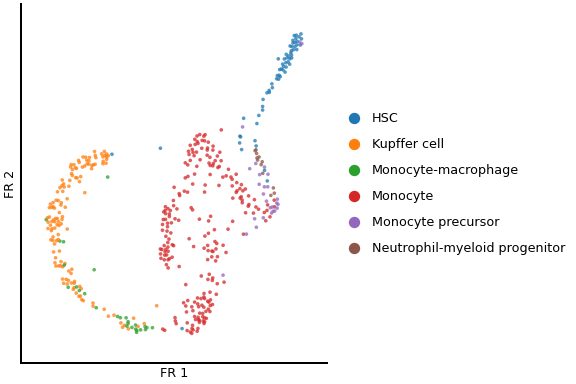

Figure 3: scVI-based force-directed graph embedding

```python
sc.pl.draw_graph(
    ad_blood,
    color='celltype',
    title='',
    alpha=0.75,
    size=30,
    show=False
)
plt.gca().set_xlabel('FR 1')
plt.gca().set_ylabel('FR 2')
plt.show()
```

## Diffusion map embedding

Lastly, we estimate a diffusion map embedding in 15 dimensions. This algorithm is specifically designed to preserve transitional structures, but in my experience it usually only works well on datasets with very simple trajectories.

```python
sc.tl.diffmap(
    ad_blood,
    random_state=312,
    n_comps=16
)
ad_blood.obsm['X_diffmap_old'] = ad_blood.obsm['X_diffmap']
ad_blood.obsm['X_diffmap'] = ad_blood.obsm['X_diffmap'][:, 1:]
```

Like the UMAP embedding the diffusion map embedding is pretty angular, but it recapitulates the biology well. Altogether, the `scVI` integration seems to have worked correctly as all embedding algorithms perform reasonably well.

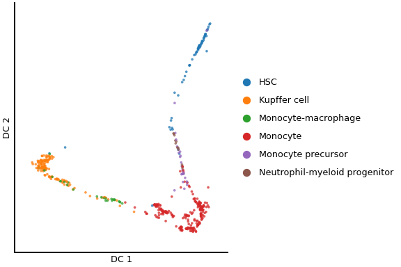

Figure 4: scVI-based diffusion map embedding

```python
sc.pl.diffmap(
    ad_blood,
    color='celltype',
    title='',
    alpha=0.75,
    size=30,
    show=False
)
plt.gca().set_xlabel('DC 1')
plt.gca().set_ylabel('DC 2')
plt.show()
```

# Integration with `Harmony`

[Paper](https://doi.org/10.1038/s41592-019-0619-0), [Docs](https://github.com/slowkow/harmonypy)

## Normalization

The `Harmony` algorithm works by “correcting” a principal component embedding for batch effects. As such, we need to first normalize and variance-stabilize the data.

```python
sc.pp.normalize_total(ad_blood, target_sum=1e4)
sc.pp.log1p(ad_blood)
```

## PCA embedding

Next we scale the normalized counts and run PCA.

```python
sc.pp.scale(ad_blood)
sc.tl.pca(
    ad_blood,
    n_comps=30,
    random_state=312,
    use_highly_variable=True
)
```

The PCA embedding on its own is alright, and I don’t imagine the integration procedure will change it much.

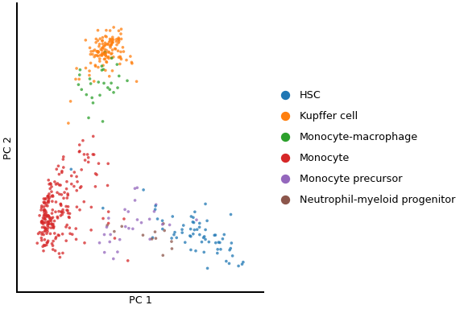

Figure 5: PCA embedding

```python
sc.pl.embedding(
    ad_blood,
    basis='pca',
    color='celltype',
    title='',
    frameon=True,
    size=30,
    alpha=0.75,
    show=False
)
plt.gca().set_xlabel('PC 1')
plt.gca().set_ylabel('PC 2')
plt.show()
```

## PCA correction with `Harmony`

```python
sc.external.pp.harmony_integrate(ad_blood, key='fetal_ID')
```

```
2023-12-08 17:54:12,890 - harmonypy - INFO - Computing initial centroids with sklearn.KMeans...
2023-12-08 17:54:12,945 - harmonypy - INFO - sklearn.KMeans initialization complete.
2023-12-08 17:54:12,946 - harmonypy - INFO - Iteration 1 of 10
2023-12-08 17:54:12,992 - harmonypy - INFO - Iteration 2 of 10
2023-12-08 17:54:13,037 - harmonypy - INFO - Iteration 3 of 10
2023-12-08 17:54:13,081 - harmonypy - INFO - Iteration 4 of 10
2023-12-08 17:54:13,127 - harmonypy - INFO - Iteration 5 of 10
2023-12-08 17:54:13,171 - harmonypy - INFO - Converged after 5 iterations
```

As expected, the corrected PCA space is pretty similar to the original one.

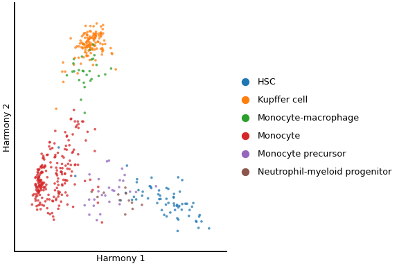

Figure 6: Harmony embedding

```python
sc.pl.embedding(
    ad_blood,
    basis='pca_harmony',
    color='celltype',
    title='',
    frameon=True,
    size=30,
    alpha=0.75,
    show=False
)
plt.gca().set_xlabel('Harmony 1')
plt.gca().set_ylabel('Harmony 2')
plt.show()
```

## SNN graph estimation

We compute $k = 20$ NNs in the `Harmony` PCA space.

```python
sc.pp.neighbors(
    ad_blood,
    n_neighbors=20,
    n_pcs=None,
    metric='cosine',
    random_state=312,
    use_rep='X_pca_harmony'
)
```

## UMAP embedding

```python
sc.tl.umap(ad_blood, random_state=312)
```

Uh oh - the UMAP embedding displays disconnected clusters of cells. This indicates that the integration didn’t perform very well, though other dimension reduction algorithms might perform better.

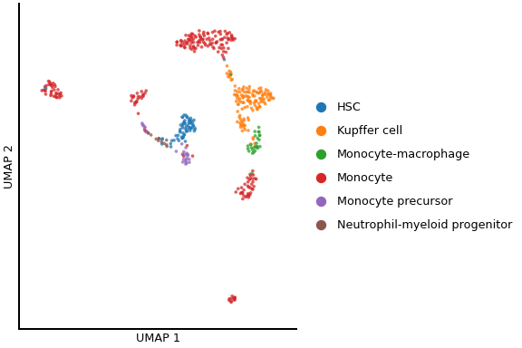

Figure 7: Harmony-based UMAP embedding

```python
sc.pl.embedding(
    ad_blood,
    basis='umap',
    color='celltype',
    title='',
    frameon=True,
    size=30,
    alpha=0.75,
    show=False
)
plt.gca().set_xlabel('UMAP 1')
plt.gca().set_ylabel('UMAP 2')
plt.show()
```

## Force-directed graph embedding

```python
sc.tl.draw_graph(
    ad_blood,
    layout='fr',
    random_state=312,
    n_jobs=2
)
```

The FR embedding shows a disconnected cluster of monocytes as well. In addition, the progression from HSCs to progenitor / mature states is not well-represented.

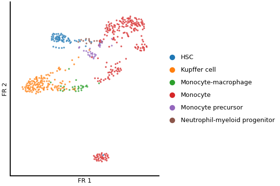

Figure 8: Harmony-based force-directed graph embedding

```python
sc.pl.draw_graph(
    ad_blood,
    color='celltype',
    title='',
    alpha=0.75,
    size=30,
    show=False
)
plt.gca().set_xlabel('FR 1')
plt.gca().set_ylabel('FR 2')
plt.show()
```

## Diffusion map embedding

```python
sc.tl.diffmap(
    ad_blood,
    random_state=312,
    n_comps=16
)
ad_blood.obsm['X_diffmap_old'] = ad_blood.obsm['X_diffmap']
ad_blood.obsm['X_diffmap'] = ad_blood.obsm['X_diffmap'][:, 1:]
```

The diffusion map embedding is also fairly disconnected and has a tiny outlier cluster.

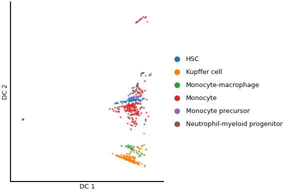

Figure 9: Harmony-based diffusion map embedding

```python
sc.pl.diffmap(
    ad_blood,
    color='celltype',
    title='',
    alpha=0.75,
    size=30,
    show=False
)
plt.gca().set_xlabel('DC 1')
plt.gca().set_ylabel('DC 2')
plt.show()
```

# Integration with `BBKNN`

[Paper](https://doi.org/10.1093/bioinformatics/btz625), [Docs](https://github.com/Teichlab/bbknn)

## Batch-specific SNN estimation

Next we try the `BBKNN` algorithm which, instead of producing an integrated embedding (as do the other methods) produces a batch-corrected neighborhood graph. We can then use that graph structure to generate UMAP and other embeddings.

```python
sc.external.pp.bbknn(
  ad_blood,
  batch_key='fetal_ID',
  use_annoy=False,
  metric='cosine',
  pynndescent_random_state=312,
  pynndescent_n_neighbors=20
)
```

```
WARNING: consider updating your call to make use of `computation`
```

## UMAP embedding

```python
sc.tl.umap(ad_blood, random_state=312)
```

The UMAP is somewhat smoothly-connected, but the biological sequence of celltypes isn’t correct.

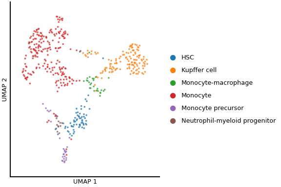

Figure 10: BBKNN-based UMAP embedding

```python
sc.pl.embedding(
    ad_blood,
    basis='umap',
    color='celltype',
    title='',
    frameon=True,
    size=30,
    alpha=0.75,
    show=False
)
plt.gca().set_xlabel('UMAP 1')
plt.gca().set_ylabel('UMAP 2')
plt.show()
```

## Force-directed graph embedding

```python
sc.tl.draw_graph(
    ad_blood,
    layout='fr',
    random_state=312,
    n_jobs=2
)
```

The FR embedding suffers from the same issue.

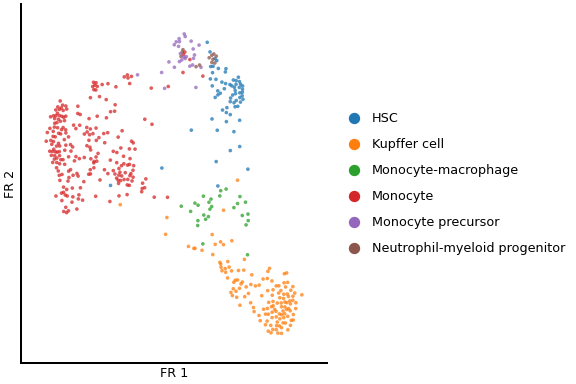

Figure 11: BBKNN-based force-directed graph embedding

```python
sc.pl.draw_graph(
    ad_blood,
    color='celltype',
    title='',
    alpha=0.75,
    size=30,
    show=False
)
plt.gca().set_xlabel('FR 1')
plt.gca().set_ylabel('FR 2')
plt.show()
```

## Diffusion map embedding

```python
sc.tl.diffmap(
    ad_blood,
    random_state=312,
    n_comps=16
)
ad_blood.obsm['X_diffmap_old'] = ad_blood.obsm['X_diffmap']
ad_blood.obsm['X_diffmap'] = ad_blood.obsm['X_diffmap'][:, 1:]
```

The diffusion map embedding also misplaces the monocyte phenotype.

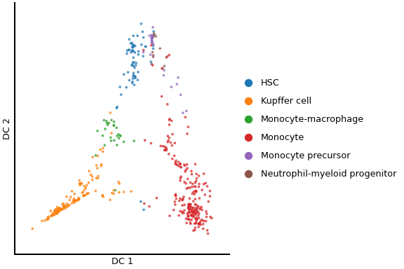

Figure 12: BBKNN-based diffusion map embedding

```python
sc.pl.diffmap(
    ad_blood,
    color='celltype',
    title='',
    alpha=0.75,
    size=30,
    show=False
)
plt.gca().set_xlabel('DC 1')
plt.gca().set_ylabel('DC 2')
plt.show()
```

# Integration with `Scanorama`

[Paper](https://doi.org/10.1038/s41587-019-0113-3), [Docs](https://github.com/brianhie/scanorama)

## Batch-correcting integration

The last method we’ll try is `Scanorama`. Like `scVi` and `Harmony` this algorithm produces a corrected low-dimensional embedding.

```python
sc.external.pp.scanorama_integrate(
  ad_blood,
  key='fetal_ID',
  basis='X_pca',
  knn=20
)
```

```
[[0. 1.]
 [0. 0.]]
Processing datasets F11_female_12+3PCW <=> F17_male_9+1PCW
```

## SNN graph estimation

We identify $k = 20$ NNs in the integrated space.

```python
sc.pp.neighbors(
    ad_blood,
    n_neighbors=20,
    n_pcs=None,
    metric='cosine',
    random_state=312,
    use_rep='X_scanorama'
)
```

## UMAP embedding

```python
sc.tl.umap(ad_blood, random_state=312)
```

With UMAP the celltype progression is represented correctly, though the transition from the monocyte-macrophage phenotype to the mature Kupffer cells is a bit wonky.

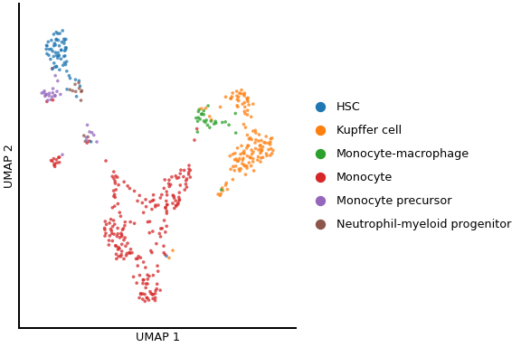

Figure 13: Scanorama-based UMAP embedding

```python
sc.pl.embedding(
    ad_blood,
    basis='umap',
    color='celltype',
    title='',
    frameon=True,
    size=30,
    alpha=0.75,
    show=False
)
plt.gca().set_xlabel('UMAP 1')
plt.gca().set_ylabel('UMAP 2')
plt.show()
```

## Force-directed graph embedding

```python
sc.tl.draw_graph(
    ad_blood,
    layout='fr',
    random_state=312,
    n_jobs=2
)
```

The FR embedding is a bit worse and isn’t very smoothly connected.

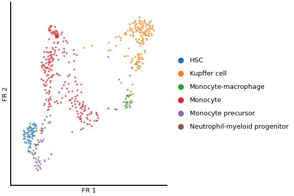

```python
sc.pl.draw_graph(
    ad_blood,
    color='celltype',
    title='',
    alpha=0.75,
    size=30,
    show=False
)
plt.gca().set_xlabel('FR 1')
plt.gca().set_ylabel('FR 2')
plt.show()
```

## Diffusion map embedding

```python
sc.tl.diffmap(
    ad_blood,
    random_state=312,
    n_comps=16
)
ad_blood.obsm['X_diffmap_old'] = ad_blood.obsm['X_diffmap']
ad_blood.obsm['X_diffmap'] = ad_blood.obsm['X_diffmap'][:, 1:]
```

The diffusion map embedding is mostly OK, but there’s a weird outlier cluster of monocytes located at the minimum of the first component.

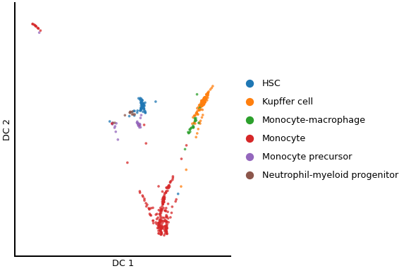

Figure 15: Scanorama-based diffusion map embedding

```python
sc.pl.diffmap(
    ad_blood,
    color='celltype',
    title='',
    alpha=0.75,
    size=30,
    show=False
)
plt.gca().set_xlabel('DC 1')
plt.gca().set_ylabel('DC 2')
plt.show()
```

# Conclusions

Overall, it seems that the `scVI` latent representation of the data performed the best. As for embeddings of that integrated space, I would probably choose the force-directed graph layout, though UMAP also performed well. The primary drawback of this method isn’t readily apparent with this dataset - computation time. I’ve experienced long runtimes (1h+) on even medium-sized datasets of around 25-40k cells. This can make it difficult to experiment and tweak the algorithm’s parameters, but overall it tends to perform well without much tuning. As for non-deep learning methods, I would subjectively say that `Scanorama` provided the second-best embeddings, though I’ve also had good experiences with the R implementation of `Harmony`. As always, it’s important to try multiple methods and compare results both visually and quantitatively.